# complete_the_square_B

## complete_the_square_B

#### Question

1. A large square comprises a yellow square, two congruent blue rectangles, and a red square.

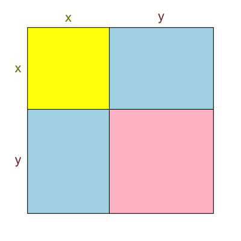

   The yellow square has an area of $x^2$ square units. The two blue rectangles have a combined area of $28x$ square units.

   What is the area, in square units, of the red square?

#### Question

2. A large square comprises a yellow square, two congruent blue rectangles, and a red square.

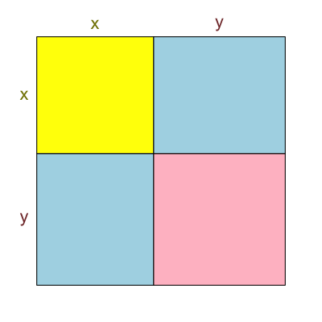

   The yellow square has an area of $x^2$ square units. The two blue rectangles have a combined area of $18x$ square units.

   What is the area, in square units, of the red square?

#### Question

3. A large square comprises a yellow square, two congruent blue rectangles, and a red square.

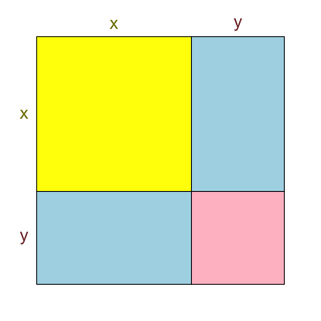

   The yellow square has an area of $x^2$ square units. The two blue rectangles have a combined area of $36x$ square units.

   What is the area, in square units, of the red square?

#### Question

4. A large square comprises a yellow square, two congruent blue rectangles, and a red square.

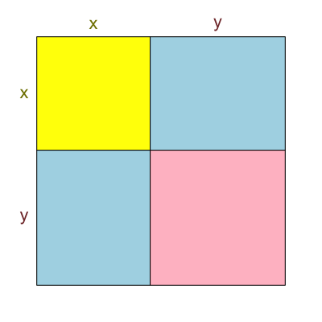

   The yellow square has an area of $x^2$ square units. The two blue rectangles have a combined area of $50x$ square units.

   What is the area, in square units, of the red square?

#### Question

5. A large square comprises a yellow square, two congruent blue rectangles, and a red square.

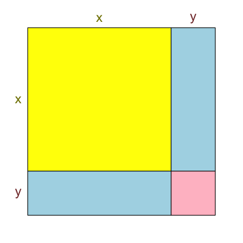

   The yellow square has an area of $x^2$ square units. The two blue rectangles have a combined area of $16x$ square units.

   What is the area, in square units, of the red square?

#### Question

6. A large square comprises a yellow square, two congruent blue rectangles, and a red square.

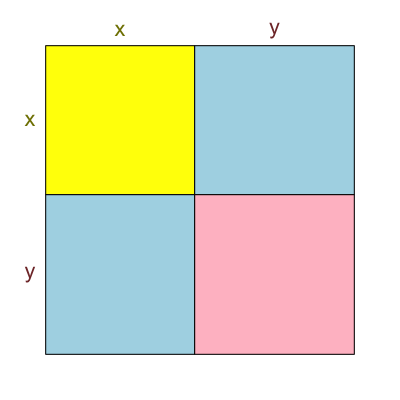

   The yellow square has an area of $x^2$ square units. The two blue rectangles have a combined area of $60x$ square units.

   What is the area, in square units, of the red square?